# Day 2

```python
import pandas as pd
```

```python
money=pd.read_excel("usd_exchange_rate.xlsx") #dataframe
money
```

|  | nominal | data | curs | cdx |
| --- | --- | --- | --- | --- |
| 0 | 1 | 2018-01-10 | 57.0463 | Доллар США |
| 1 | 1 | 2018-01-11 | 56.8734 | Доллар США |
| 2 | 1 | 2018-01-12 | 56.9957 | Доллар США |
| 3 | 1 | 2018-01-13 | 56.6019 | Доллар США |
| 4 | 1 | 2018-01-16 | 56.3569 | Доллар США |
| 5 | 1 | 2018-01-17 | 56.3878 | Доллар США |
| 6 | 1 | 2018-01-18 | 56.5925 | Доллар США |
| 7 | 1 | 2018-01-19 | 56.7597 | Доллар США |
| 8 | 1 | 2018-01-20 | 56.5892 | Доллар США |
| 9 | 1 | 2018-01-23 | 56.6261 | Доллар США |
| 10 | 1 | 2018-01-24 | 56.4115 | Доллар США |
| 11 | 1 | 2018-01-25 | 56.3888 | Доллар США |
| 12 | 1 | 2018-01-26 | 55.9288 | Доллар США |
| 13 | 1 | 2018-01-27 | 55.8288 | Доллар США |
| 14 | 1 | 2018-01-30 | 56.2908 | Доллар США |
| 15 | 1 | 2018-01-31 | 56.2914 | Доллар США |
| 16 | 1 | 2018-02-01 | 56.1840 | Доллар США |
| 17 | 1 | 2018-02-02 | 56.2613 | Доллар США |
| 18 | 1 | 2018-02-03 | 56.0408 | Доллар США |
| 19 | 1 | 2018-02-06 | 56.6278 | Доллар США |
| 20 | 1 | 2018-02-07 | 57.2196 | Доллар США |
| 21 | 1 | 2018-02-08 | 56.9533 | Доллар США |
| 22 | 1 | 2018-02-09 | 57.6736 | Доллар США |
| 23 | 1 | 2018-02-10 | 58.1718 | Доллар США |
| 24 | 1 | 2018-02-13 | 58.0171 | Доллар США |
| 25 | 1 | 2018-02-14 | 57.7701 | Доллар США |
| 26 | 1 | 2018-02-15 | 57.5899 | Доллар США |
| 27 | 1 | 2018-02-16 | 56.5918 | Доллар США |
| 28 | 1 | 2018-02-17 | 56.3554 | Доллар США |
| 29 | 1 | 2018-02-20 | 56.3438 | Доллар США |
| ... | ... | ... | ... | ... |
| 487 | 1 | 2019-12-24 | 62.2499 | Доллар США |
| 488 | 1 | 2019-12-25 | 62.1673 | Доллар США |
| 489 | 1 | 2019-12-26 | 61.7164 | Доллар США |
| 490 | 1 | 2019-12-27 | 61.7676 | Доллар США |
| 491 | 1 | 2019-12-28 | 62.0315 | Доллар США |
| 492 | 1 | 2019-12-31 | 61.9057 | Доллар США |
| 493 | 1 | 2020-01-01 | 61.9057 | Доллар США |
| 494 | 1 | 2020-01-10 | 61.2340 | Доллар США |
| 495 | 1 | 2020-01-11 | 61.2632 | Доллар США |
| 496 | 1 | 2020-01-14 | 60.9474 | Доллар США |
| 497 | 1 | 2020-01-15 | 61.4140 | Доллар США |
| 498 | 1 | 2020-01-16 | 61.4328 | Доллар США |
| 499 | 1 | 2020-01-17 | 61.5694 | Доллар США |
| 500 | 1 | 2020-01-18 | 61.5333 | Доллар США |
| 501 | 1 | 2020-01-21 | 61.4654 | Доллар США |
| 502 | 1 | 2020-01-22 | 61.8552 | Доллар США |
| 503 | 1 | 2020-01-23 | 61.8343 | Доллар США |
| 504 | 1 | 2020-01-24 | 61.9515 | Доллар США |
| 505 | 1 | 2020-01-25 | 61.8031 | Доллар США |
| 506 | 1 | 2020-01-28 | 62.3380 | Доллар США |
| 507 | 1 | 2020-01-29 | 62.8299 | Доллар США |
| 508 | 1 | 2020-01-30 | 62.3934 | Доллар США |
| 509 | 1 | 2020-01-31 | 63.0359 | Доллар США |
| 510 | 1 | 2020-02-01 | 63.1385 | Доллар США |
| 511 | 1 | 2020-02-04 | 63.9091 | Доллар США |
| 512 | 1 | 2020-02-05 | 63.4342 | Доллар США |
| 513 | 1 | 2020-02-06 | 63.1742 | Доллар США |
| 514 | 1 | 2020-02-07 | 62.7977 | Доллар США |
| 515 | 1 | 2020-02-08 | 63.4720 | Доллар США |
| 516 | 1 | 2020-02-11 | 63.7708 | Доллар США |

517 rows × 4 columns

```python
money.head(5) #More comfortable is to look at the first five rows
```

|  | nominal | data | curs | cdx |
| --- | --- | --- | --- | --- |
| 0 | 1 | 2018-01-10 | 57.0463 | Доллар США |
| 1 | 1 | 2018-01-11 | 56.8734 | Доллар США |
| 2 | 1 | 2018-01-12 | 56.9957 | Доллар США |
| 3 | 1 | 2018-01-13 | 56.6019 | Доллар США |
| 4 | 1 | 2018-01-16 | 56.3569 | Доллар США |

```python
money.tail(5) #Looking at the last 5 rows
```

|  | nominal | data | curs | cdx |
| --- | --- | --- | --- | --- |
| 512 | 1 | 2020-02-05 | 63.4342 | Доллар США |
| 513 | 1 | 2020-02-06 | 63.1742 | Доллар США |
| 514 | 1 | 2020-02-07 | 62.7977 | Доллар США |
| 515 | 1 | 2020-02-08 | 63.4720 | Доллар США |
| 516 | 1 | 2020-02-11 | 63.7708 | Доллар США |

```python
past=7*4 #According to the data in the four last weeks,
future=7 #We will predict the value in the next week
```

```python
values=money.curs #This is the value we want to predict
```

```python
start=past
end=len(values)-future
```

```python
print(f"We will start from {start} days ago and will predict data till the {end} days")
```

```
We will start from 28 days ago and will predict data till the 510 days
```

```python
days=end-start
print("We will predict values for ", days, "days")
```

```
We will predict values for  482 days
```

```python
raw_df=[]
for i in range(start, end):
    past_and_future_values=values[(i-past):(i+future)] #Data with we work with (4 weeks past and the next one)
    raw_df.append(list(past_and_future_values))
```

```python
raw_df
```

[output not shown]

[output cut: 16815 more lines]

[output not shown]

```python
past_columns=[f"_past{i}" for i in range(past)]
future_columns=[f"_future{i}" for i in range(future)]
```

```python
past_columns
```

```
['_past0',
 '_past1',
 '_past2',
 '_past3',
 '_past4',
 '_past5',
 '_past6',
 '_past7',
 '_past8',
 '_past9',
 '_past10',
 '_past11',
 '_past12',
 '_past13',
 '_past14',
 '_past15',
 '_past16',
 '_past17',
 '_past18',
 '_past19',
 '_past20',
 '_past21',
 '_past22',
 '_past23',
 '_past24',
 '_past25',
 '_past26',
 '_past27']
```

```python
future_columns
```

```
['_future0',
 '_future1',
 '_future2',
 '_future3',
 '_future4',
 '_future5',
 '_future6']
```

```python
#Merging the data and converting it into a dataframe
df=pd.DataFrame(raw_df,columns=(past_columns+future_columns))
```

```python
df.head(5)
```

|  | _past0 | _past1 | _past2 | _past3 | _past4 | _past5 | _past6 | _past7 | _past8 | _past9 | ... | _past25 | _past26 | _past27 | _future0 | _future1 | _future2 | _future3 | _future4 | _future5 | _future6 |
| --- | --- | --- | --- | --- | --- | --- | --- | --- | --- | --- | --- | --- | --- | --- | --- | --- | --- | --- | --- | --- | --- |
| 0 | 57.0463 | 56.8734 | 56.9957 | 56.6019 | 56.3569 | 56.3878 | 56.5925 | 56.7597 | 56.5892 | 56.6261 | ... | 57.7701 | 57.5899 | 56.5918 | 56.3554 | 56.3438 | 56.5201 | 56.6537 | 56.7608 | 55.9208 | 55.6717 |
| 1 | 56.8734 | 56.9957 | 56.6019 | 56.3569 | 56.3878 | 56.5925 | 56.7597 | 56.5892 | 56.6261 | 56.4115 | ... | 57.5899 | 56.5918 | 56.3554 | 56.3438 | 56.5201 | 56.6537 | 56.7608 | 55.9208 | 55.6717 | 56.3742 |
| 2 | 56.9957 | 56.6019 | 56.3569 | 56.3878 | 56.5925 | 56.7597 | 56.5892 | 56.6261 | 56.4115 | 56.3888 | ... | 56.5918 | 56.3554 | 56.3438 | 56.5201 | 56.6537 | 56.7608 | 55.9208 | 55.6717 | 56.3742 | 56.4334 |
| 3 | 56.6019 | 56.3569 | 56.3878 | 56.5925 | 56.7597 | 56.5892 | 56.6261 | 56.4115 | 56.3888 | 55.9288 | ... | 56.3554 | 56.3438 | 56.5201 | 56.6537 | 56.7608 | 55.9208 | 55.6717 | 56.3742 | 56.4334 | 56.6616 |
| 4 | 56.3569 | 56.3878 | 56.5925 | 56.7597 | 56.5892 | 56.6261 | 56.4115 | 56.3888 | 55.9288 | 55.8288 | ... | 56.3438 | 56.5201 | 56.6537 | 56.7608 | 55.9208 | 55.6717 | 56.3742 | 56.4334 | 56.6616 | 57.1000 |

5 rows × 35 columns

```python
df.shape #Dimension of the data
```

```
(482, 35)
```

Then there are 482 rows and 35 columns

```python
money.head(10)
```

|  | nominal | data | curs | cdx |
| --- | --- | --- | --- | --- |
| 0 | 1 | 2018-01-10 | 57.0463 | Доллар США |
| 1 | 1 | 2018-01-11 | 56.8734 | Доллар США |
| 2 | 1 | 2018-01-12 | 56.9957 | Доллар США |
| 3 | 1 | 2018-01-13 | 56.6019 | Доллар США |
| 4 | 1 | 2018-01-16 | 56.3569 | Доллар США |
| 5 | 1 | 2018-01-17 | 56.3878 | Доллар США |
| 6 | 1 | 2018-01-18 | 56.5925 | Доллар США |
| 7 | 1 | 2018-01-19 | 56.7597 | Доллар США |
| 8 | 1 | 2018-01-20 | 56.5892 | Доллар США |
| 9 | 1 | 2018-01-23 | 56.6261 | Доллар США |

```python
money.tail(10)#Last 10 rows
```

|  | nominal | data | curs | cdx |
| --- | --- | --- | --- | --- |
| 507 | 1 | 2020-01-29 | 62.8299 | Доллар США |
| 508 | 1 | 2020-01-30 | 62.3934 | Доллар США |
| 509 | 1 | 2020-01-31 | 63.0359 | Доллар США |
| 510 | 1 | 2020-02-01 | 63.1385 | Доллар США |
| 511 | 1 | 2020-02-04 | 63.9091 | Доллар США |
| 512 | 1 | 2020-02-05 | 63.4342 | Доллар США |
| 513 | 1 | 2020-02-06 | 63.1742 | Доллар США |
| 514 | 1 | 2020-02-07 | 62.7977 | Доллар США |
| 515 | 1 | 2020-02-08 | 63.4720 | Доллар США |
| 516 | 1 | 2020-02-11 | 63.7708 | Доллар США |

```python
money.take([40,45])
```

|  | nominal | data | curs | cdx |
| --- | --- | --- | --- | --- |
| 40 | 1 | 2018-03-08 | 56.8011 | Доллар США |
| 45 | 1 | 2018-03-17 | 57.4942 | Доллар США |

We will take X as the past columns because these data we already know and we will use it for predicting the future

```python
X=df[past_columns]
X
```

|  | _past0 | _past1 | _past2 | _past3 | _past4 | _past5 | _past6 | _past7 | _past8 | _past9 | ... | _past18 | _past19 | _past20 | _past21 | _past22 | _past23 | _past24 | _past25 | _past26 | _past27 |
| --- | --- | --- | --- | --- | --- | --- | --- | --- | --- | --- | --- | --- | --- | --- | --- | --- | --- | --- | --- | --- | --- |
| 0 | 57.0463 | 56.8734 | 56.9957 | 56.6019 | 56.3569 | 56.3878 | 56.5925 | 56.7597 | 56.5892 | 56.6261 | ... | 56.0408 | 56.6278 | 57.2196 | 56.9533 | 57.6736 | 58.1718 | 58.0171 | 57.7701 | 57.5899 | 56.5918 |
| 1 | 56.8734 | 56.9957 | 56.6019 | 56.3569 | 56.3878 | 56.5925 | 56.7597 | 56.5892 | 56.6261 | 56.4115 | ... | 56.6278 | 57.2196 | 56.9533 | 57.6736 | 58.1718 | 58.0171 | 57.7701 | 57.5899 | 56.5918 | 56.3554 |
| 2 | 56.9957 | 56.6019 | 56.3569 | 56.3878 | 56.5925 | 56.7597 | 56.5892 | 56.6261 | 56.4115 | 56.3888 | ... | 57.2196 | 56.9533 | 57.6736 | 58.1718 | 58.0171 | 57.7701 | 57.5899 | 56.5918 | 56.3554 | 56.3438 |
| 3 | 56.6019 | 56.3569 | 56.3878 | 56.5925 | 56.7597 | 56.5892 | 56.6261 | 56.4115 | 56.3888 | 55.9288 | ... | 56.9533 | 57.6736 | 58.1718 | 58.0171 | 57.7701 | 57.5899 | 56.5918 | 56.3554 | 56.3438 | 56.5201 |
| 4 | 56.3569 | 56.3878 | 56.5925 | 56.7597 | 56.5892 | 56.6261 | 56.4115 | 56.3888 | 55.9288 | 55.8288 | ... | 57.6736 | 58.1718 | 58.0171 | 57.7701 | 57.5899 | 56.5918 | 56.3554 | 56.3438 | 56.5201 | 56.6537 |
| 5 | 56.3878 | 56.5925 | 56.7597 | 56.5892 | 56.6261 | 56.4115 | 56.3888 | 55.9288 | 55.8288 | 56.2908 | ... | 58.1718 | 58.0171 | 57.7701 | 57.5899 | 56.5918 | 56.3554 | 56.3438 | 56.5201 | 56.6537 | 56.7608 |
| 6 | 56.5925 | 56.7597 | 56.5892 | 56.6261 | 56.4115 | 56.3888 | 55.9288 | 55.8288 | 56.2908 | 56.2914 | ... | 58.0171 | 57.7701 | 57.5899 | 56.5918 | 56.3554 | 56.3438 | 56.5201 | 56.6537 | 56.7608 | 55.9208 |
| 7 | 56.7597 | 56.5892 | 56.6261 | 56.4115 | 56.3888 | 55.9288 | 55.8288 | 56.2908 | 56.2914 | 56.1840 | ... | 57.7701 | 57.5899 | 56.5918 | 56.3554 | 56.3438 | 56.5201 | 56.6537 | 56.7608 | 55.9208 | 55.6717 |
| 8 | 56.5892 | 56.6261 | 56.4115 | 56.3888 | 55.9288 | 55.8288 | 56.2908 | 56.2914 | 56.1840 | 56.2613 | ... | 57.5899 | 56.5918 | 56.3554 | 56.3438 | 56.5201 | 56.6537 | 56.7608 | 55.9208 | 55.6717 | 56.3742 |
| 9 | 56.6261 | 56.4115 | 56.3888 | 55.9288 | 55.8288 | 56.2908 | 56.2914 | 56.1840 | 56.2613 | 56.0408 | ... | 56.5918 | 56.3554 | 56.3438 | 56.5201 | 56.6537 | 56.7608 | 55.9208 | 55.6717 | 56.3742 | 56.4334 |
| 10 | 56.4115 | 56.3888 | 55.9288 | 55.8288 | 56.2908 | 56.2914 | 56.1840 | 56.2613 | 56.0408 | 56.6278 | ... | 56.3554 | 56.3438 | 56.5201 | 56.6537 | 56.7608 | 55.9208 | 55.6717 | 56.3742 | 56.4334 | 56.6616 |
| 11 | 56.3888 | 55.9288 | 55.8288 | 56.2908 | 56.2914 | 56.1840 | 56.2613 | 56.0408 | 56.6278 | 57.2196 | ... | 56.3438 | 56.5201 | 56.6537 | 56.7608 | 55.9208 | 55.6717 | 56.3742 | 56.4334 | 56.6616 | 57.1000 |
| 12 | 55.9288 | 55.8288 | 56.2908 | 56.2914 | 56.1840 | 56.2613 | 56.0408 | 56.6278 | 57.2196 | 56.9533 | ... | 56.5201 | 56.6537 | 56.7608 | 55.9208 | 55.6717 | 56.3742 | 56.4334 | 56.6616 | 57.1000 | 56.5041 |
| 13 | 55.8288 | 56.2908 | 56.2914 | 56.1840 | 56.2613 | 56.0408 | 56.6278 | 57.2196 | 56.9533 | 57.6736 | ... | 56.6537 | 56.7608 | 55.9208 | 55.6717 | 56.3742 | 56.4334 | 56.6616 | 57.1000 | 56.5041 | 56.8011 |
| 14 | 56.2908 | 56.2914 | 56.1840 | 56.2613 | 56.0408 | 56.6278 | 57.2196 | 56.9533 | 57.6736 | 58.1718 | ... | 56.7608 | 55.9208 | 55.6717 | 56.3742 | 56.4334 | 56.6616 | 57.1000 | 56.5041 | 56.8011 | 56.6122 |
| 15 | 56.2914 | 56.1840 | 56.2613 | 56.0408 | 56.6278 | 57.2196 | 56.9533 | 57.6736 | 58.1718 | 58.0171 | ... | 55.9208 | 55.6717 | 56.3742 | 56.4334 | 56.6616 | 57.1000 | 56.5041 | 56.8011 | 56.6122 | 56.9359 |
| 16 | 56.1840 | 56.2613 | 56.0408 | 56.6278 | 57.2196 | 56.9533 | 57.6736 | 58.1718 | 58.0171 | 57.7701 | ... | 55.6717 | 56.3742 | 56.4334 | 56.6616 | 57.1000 | 56.5041 | 56.8011 | 56.6122 | 56.9359 | 56.9372 |
| 17 | 56.2613 | 56.0408 | 56.6278 | 57.2196 | 56.9533 | 57.6736 | 58.1718 | 58.0171 | 57.7701 | 57.5899 | ... | 56.3742 | 56.4334 | 56.6616 | 57.1000 | 56.5041 | 56.8011 | 56.6122 | 56.9359 | 56.9372 | 57.0188 |
| 18 | 56.0408 | 56.6278 | 57.2196 | 56.9533 | 57.6736 | 58.1718 | 58.0171 | 57.7701 | 57.5899 | 56.5918 | ... | 56.4334 | 56.6616 | 57.1000 | 56.5041 | 56.8011 | 56.6122 | 56.9359 | 56.9372 | 57.0188 | 57.4942 |
| 19 | 56.6278 | 57.2196 | 56.9533 | 57.6736 | 58.1718 | 58.0171 | 57.7701 | 57.5899 | 56.5918 | 56.3554 | ... | 56.6616 | 57.1000 | 56.5041 | 56.8011 | 56.6122 | 56.9359 | 56.9372 | 57.0188 | 57.4942 | 57.5521 |
| 20 | 57.2196 | 56.9533 | 57.6736 | 58.1718 | 58.0171 | 57.7701 | 57.5899 | 56.5918 | 56.3554 | 56.3438 | ... | 57.1000 | 56.5041 | 56.8011 | 56.6122 | 56.9359 | 56.9372 | 57.0188 | 57.4942 | 57.5521 | 57.7033 |
| 21 | 56.9533 | 57.6736 | 58.1718 | 58.0171 | 57.7701 | 57.5899 | 56.5918 | 56.3554 | 56.3438 | 56.5201 | ... | 56.5041 | 56.8011 | 56.6122 | 56.9359 | 56.9372 | 57.0188 | 57.4942 | 57.5521 | 57.7033 | 57.4954 |
| 22 | 57.6736 | 58.1718 | 58.0171 | 57.7701 | 57.5899 | 56.5918 | 56.3554 | 56.3438 | 56.5201 | 56.6537 | ... | 56.8011 | 56.6122 | 56.9359 | 56.9372 | 57.0188 | 57.4942 | 57.5521 | 57.7033 | 57.4954 | 56.8391 |
| 23 | 58.1718 | 58.0171 | 57.7701 | 57.5899 | 56.5918 | 56.3554 | 56.3438 | 56.5201 | 56.6537 | 56.7608 | ... | 56.6122 | 56.9359 | 56.9372 | 57.0188 | 57.4942 | 57.5521 | 57.7033 | 57.4954 | 56.8391 | 57.1072 |
| 24 | 58.0171 | 57.7701 | 57.5899 | 56.5918 | 56.3554 | 56.3438 | 56.5201 | 56.6537 | 56.7608 | 55.9208 | ... | 56.9359 | 56.9372 | 57.0188 | 57.4942 | 57.5521 | 57.7033 | 57.4954 | 56.8391 | 57.1072 | 57.0039 |
| 25 | 57.7701 | 57.5899 | 56.5918 | 56.3554 | 56.3438 | 56.5201 | 56.6537 | 56.7608 | 55.9208 | 55.6717 | ... | 56.9372 | 57.0188 | 57.4942 | 57.5521 | 57.7033 | 57.4954 | 56.8391 | 57.1072 | 57.0039 | 57.1747 |
| 26 | 57.5899 | 56.5918 | 56.3554 | 56.3438 | 56.5201 | 56.6537 | 56.7608 | 55.9208 | 55.6717 | 56.3742 | ... | 57.0188 | 57.4942 | 57.5521 | 57.7033 | 57.4954 | 56.8391 | 57.1072 | 57.0039 | 57.1747 | 57.5598 |
| 27 | 56.5918 | 56.3554 | 56.3438 | 56.5201 | 56.6537 | 56.7608 | 55.9208 | 55.6717 | 56.3742 | 56.4334 | ... | 57.4942 | 57.5521 | 57.7033 | 57.4954 | 56.8391 | 57.1072 | 57.0039 | 57.1747 | 57.5598 | 57.7626 |
| 28 | 56.3554 | 56.3438 | 56.5201 | 56.6537 | 56.7608 | 55.9208 | 55.6717 | 56.3742 | 56.4334 | 56.6616 | ... | 57.5521 | 57.7033 | 57.4954 | 56.8391 | 57.1072 | 57.0039 | 57.1747 | 57.5598 | 57.7626 | 57.2649 |
| 29 | 56.3438 | 56.5201 | 56.6537 | 56.7608 | 55.9208 | 55.6717 | 56.3742 | 56.4334 | 56.6616 | 57.1000 | ... | 57.7033 | 57.4954 | 56.8391 | 57.1072 | 57.0039 | 57.1747 | 57.5598 | 57.7626 | 57.2649 | 57.2850 |
| ... | ... | ... | ... | ... | ... | ... | ... | ... | ... | ... | ... | ... | ... | ... | ... | ... | ... | ... | ... | ... | ... |
| 452 | 64.0316 | 63.2480 | 63.5880 | 63.7298 | 63.7295 | 63.9121 | 63.8530 | 64.2009 | 64.2101 | 63.8881 | ... | 64.1005 | 64.0817 | 64.4097 | 64.1401 | 64.1948 | 63.8135 | 63.7185 | 63.7244 | 63.5788 | 63.5653 |
| 453 | 63.2480 | 63.5880 | 63.7298 | 63.7295 | 63.9121 | 63.8530 | 64.2009 | 64.2101 | 63.8881 | 63.7542 | ... | 64.0817 | 64.4097 | 64.1401 | 64.1948 | 63.8135 | 63.7185 | 63.7244 | 63.5788 | 63.5653 | 63.2257 |
| 454 | 63.5880 | 63.7298 | 63.7295 | 63.9121 | 63.8530 | 64.2009 | 64.2101 | 63.8881 | 63.7542 | 63.7730 | ... | 64.4097 | 64.1401 | 64.1948 | 63.8135 | 63.7185 | 63.7244 | 63.5788 | 63.5653 | 63.2257 | 62.5544 |
| 455 | 63.7298 | 63.7295 | 63.9121 | 63.8530 | 64.2009 | 64.2101 | 63.8881 | 63.7542 | 63.7730 | 64.0213 | ... | 64.1401 | 64.1948 | 63.8135 | 63.7185 | 63.7244 | 63.5788 | 63.5653 | 63.2257 | 62.5544 | 62.7686 |
| 456 | 63.7295 | 63.9121 | 63.8530 | 64.2009 | 64.2101 | 63.8881 | 63.7542 | 63.7730 | 64.0213 | 63.8430 | ... | 64.1948 | 63.8135 | 63.7185 | 63.7244 | 63.5788 | 63.5653 | 63.2257 | 62.5544 | 62.7686 | 62.5326 |
| 457 | 63.9121 | 63.8530 | 64.2009 | 64.2101 | 63.8881 | 63.7542 | 63.7730 | 64.0213 | 63.8430 | 63.7101 | ... | 63.8135 | 63.7185 | 63.7244 | 63.5788 | 63.5653 | 63.2257 | 62.5544 | 62.7686 | 62.5326 | 62.5831 |
| 458 | 63.8530 | 64.2009 | 64.2101 | 63.8881 | 63.7542 | 63.7730 | 64.0213 | 63.8430 | 63.7101 | 63.7637 | ... | 63.7185 | 63.7244 | 63.5788 | 63.5653 | 63.2257 | 62.5544 | 62.7686 | 62.5326 | 62.5831 | 62.5283 |
| 459 | 64.2009 | 64.2101 | 63.8881 | 63.7542 | 63.7730 | 64.0213 | 63.8430 | 63.7101 | 63.7637 | 64.0239 | ... | 63.7244 | 63.5788 | 63.5653 | 63.2257 | 62.5544 | 62.7686 | 62.5326 | 62.5831 | 62.5283 | 62.4071 |
| 460 | 64.2101 | 63.8881 | 63.7542 | 63.7730 | 64.0213 | 63.8430 | 63.7101 | 63.7637 | 64.0239 | 63.9722 | ... | 63.5788 | 63.5653 | 63.2257 | 62.5544 | 62.7686 | 62.5326 | 62.5831 | 62.5283 | 62.4071 | 62.2499 |
| 461 | 63.8881 | 63.7542 | 63.7730 | 64.0213 | 63.8430 | 63.7101 | 63.7637 | 64.0239 | 63.9722 | 64.1005 | ... | 63.5653 | 63.2257 | 62.5544 | 62.7686 | 62.5326 | 62.5831 | 62.5283 | 62.4071 | 62.2499 | 62.1673 |
| 462 | 63.7542 | 63.7730 | 64.0213 | 63.8430 | 63.7101 | 63.7637 | 64.0239 | 63.9722 | 64.1005 | 64.0817 | ... | 63.2257 | 62.5544 | 62.7686 | 62.5326 | 62.5831 | 62.5283 | 62.4071 | 62.2499 | 62.1673 | 61.7164 |
| 463 | 63.7730 | 64.0213 | 63.8430 | 63.7101 | 63.7637 | 64.0239 | 63.9722 | 64.1005 | 64.0817 | 64.4097 | ... | 62.5544 | 62.7686 | 62.5326 | 62.5831 | 62.5283 | 62.4071 | 62.2499 | 62.1673 | 61.7164 | 61.7676 |
| 464 | 64.0213 | 63.8430 | 63.7101 | 63.7637 | 64.0239 | 63.9722 | 64.1005 | 64.0817 | 64.4097 | 64.1401 | ... | 62.7686 | 62.5326 | 62.5831 | 62.5283 | 62.4071 | 62.2499 | 62.1673 | 61.7164 | 61.7676 | 62.0315 |
| 465 | 63.8430 | 63.7101 | 63.7637 | 64.0239 | 63.9722 | 64.1005 | 64.0817 | 64.4097 | 64.1401 | 64.1948 | ... | 62.5326 | 62.5831 | 62.5283 | 62.4071 | 62.2499 | 62.1673 | 61.7164 | 61.7676 | 62.0315 | 61.9057 |
| 466 | 63.7101 | 63.7637 | 64.0239 | 63.9722 | 64.1005 | 64.0817 | 64.4097 | 64.1401 | 64.1948 | 63.8135 | ... | 62.5831 | 62.5283 | 62.4071 | 62.2499 | 62.1673 | 61.7164 | 61.7676 | 62.0315 | 61.9057 | 61.9057 |
| 467 | 63.7637 | 64.0239 | 63.9722 | 64.1005 | 64.0817 | 64.4097 | 64.1401 | 64.1948 | 63.8135 | 63.7185 | ... | 62.5283 | 62.4071 | 62.2499 | 62.1673 | 61.7164 | 61.7676 | 62.0315 | 61.9057 | 61.9057 | 61.2340 |
| 468 | 64.0239 | 63.9722 | 64.1005 | 64.0817 | 64.4097 | 64.1401 | 64.1948 | 63.8135 | 63.7185 | 63.7244 | ... | 62.4071 | 62.2499 | 62.1673 | 61.7164 | 61.7676 | 62.0315 | 61.9057 | 61.9057 | 61.2340 | 61.2632 |
| 469 | 63.9722 | 64.1005 | 64.0817 | 64.4097 | 64.1401 | 64.1948 | 63.8135 | 63.7185 | 63.7244 | 63.5788 | ... | 62.2499 | 62.1673 | 61.7164 | 61.7676 | 62.0315 | 61.9057 | 61.9057 | 61.2340 | 61.2632 | 60.9474 |
| 470 | 64.1005 | 64.0817 | 64.4097 | 64.1401 | 64.1948 | 63.8135 | 63.7185 | 63.7244 | 63.5788 | 63.5653 | ... | 62.1673 | 61.7164 | 61.7676 | 62.0315 | 61.9057 | 61.9057 | 61.2340 | 61.2632 | 60.9474 | 61.4140 |
| 471 | 64.0817 | 64.4097 | 64.1401 | 64.1948 | 63.8135 | 63.7185 | 63.7244 | 63.5788 | 63.5653 | 63.2257 | ... | 61.7164 | 61.7676 | 62.0315 | 61.9057 | 61.9057 | 61.2340 | 61.2632 | 60.9474 | 61.4140 | 61.4328 |
| 472 | 64.4097 | 64.1401 | 64.1948 | 63.8135 | 63.7185 | 63.7244 | 63.5788 | 63.5653 | 63.2257 | 62.5544 | ... | 61.7676 | 62.0315 | 61.9057 | 61.9057 | 61.2340 | 61.2632 | 60.9474 | 61.4140 | 61.4328 | 61.5694 |
| 473 | 64.1401 | 64.1948 | 63.8135 | 63.7185 | 63.7244 | 63.5788 | 63.5653 | 63.2257 | 62.5544 | 62.7686 | ... | 62.0315 | 61.9057 | 61.9057 | 61.2340 | 61.2632 | 60.9474 | 61.4140 | 61.4328 | 61.5694 | 61.5333 |
| 474 | 64.1948 | 63.8135 | 63.7185 | 63.7244 | 63.5788 | 63.5653 | 63.2257 | 62.5544 | 62.7686 | 62.5326 | ... | 61.9057 | 61.9057 | 61.2340 | 61.2632 | 60.9474 | 61.4140 | 61.4328 | 61.5694 | 61.5333 | 61.4654 |
| 475 | 63.8135 | 63.7185 | 63.7244 | 63.5788 | 63.5653 | 63.2257 | 62.5544 | 62.7686 | 62.5326 | 62.5831 | ... | 61.9057 | 61.2340 | 61.2632 | 60.9474 | 61.4140 | 61.4328 | 61.5694 | 61.5333 | 61.4654 | 61.8552 |
| 476 | 63.7185 | 63.7244 | 63.5788 | 63.5653 | 63.2257 | 62.5544 | 62.7686 | 62.5326 | 62.5831 | 62.5283 | ... | 61.2340 | 61.2632 | 60.9474 | 61.4140 | 61.4328 | 61.5694 | 61.5333 | 61.4654 | 61.8552 | 61.8343 |
| 477 | 63.7244 | 63.5788 | 63.5653 | 63.2257 | 62.5544 | 62.7686 | 62.5326 | 62.5831 | 62.5283 | 62.4071 | ... | 61.2632 | 60.9474 | 61.4140 | 61.4328 | 61.5694 | 61.5333 | 61.4654 | 61.8552 | 61.8343 | 61.9515 |
| 478 | 63.5788 | 63.5653 | 63.2257 | 62.5544 | 62.7686 | 62.5326 | 62.5831 | 62.5283 | 62.4071 | 62.2499 | ... | 60.9474 | 61.4140 | 61.4328 | 61.5694 | 61.5333 | 61.4654 | 61.8552 | 61.8343 | 61.9515 | 61.8031 |
| 479 | 63.5653 | 63.2257 | 62.5544 | 62.7686 | 62.5326 | 62.5831 | 62.5283 | 62.4071 | 62.2499 | 62.1673 | ... | 61.4140 | 61.4328 | 61.5694 | 61.5333 | 61.4654 | 61.8552 | 61.8343 | 61.9515 | 61.8031 | 62.3380 |
| 480 | 63.2257 | 62.5544 | 62.7686 | 62.5326 | 62.5831 | 62.5283 | 62.4071 | 62.2499 | 62.1673 | 61.7164 | ... | 61.4328 | 61.5694 | 61.5333 | 61.4654 | 61.8552 | 61.8343 | 61.9515 | 61.8031 | 62.3380 | 62.8299 |
| 481 | 62.5544 | 62.7686 | 62.5326 | 62.5831 | 62.5283 | 62.4071 | 62.2499 | 62.1673 | 61.7164 | 61.7676 | ... | 61.5694 | 61.5333 | 61.4654 | 61.8552 | 61.8343 | 61.9515 | 61.8031 | 62.3380 | 62.8299 | 62.3934 |

482 rows × 28 columns

Y will be the future because it is the value we want to predict

```python
Y=df[future_columns]
Y
```

|  | _future0 | _future1 | _future2 | _future3 | _future4 | _future5 | _future6 |
| --- | --- | --- | --- | --- | --- | --- | --- |
| 0 | 56.3554 | 56.3438 | 56.5201 | 56.6537 | 56.7608 | 55.9208 | 55.6717 |
| 1 | 56.3438 | 56.5201 | 56.6537 | 56.7608 | 55.9208 | 55.6717 | 56.3742 |
| 2 | 56.5201 | 56.6537 | 56.7608 | 55.9208 | 55.6717 | 56.3742 | 56.4334 |
| 3 | 56.6537 | 56.7608 | 55.9208 | 55.6717 | 56.3742 | 56.4334 | 56.6616 |
| 4 | 56.7608 | 55.9208 | 55.6717 | 56.3742 | 56.4334 | 56.6616 | 57.1000 |
| 5 | 55.9208 | 55.6717 | 56.3742 | 56.4334 | 56.6616 | 57.1000 | 56.5041 |
| 6 | 55.6717 | 56.3742 | 56.4334 | 56.6616 | 57.1000 | 56.5041 | 56.8011 |
| 7 | 56.3742 | 56.4334 | 56.6616 | 57.1000 | 56.5041 | 56.8011 | 56.6122 |
| 8 | 56.4334 | 56.6616 | 57.1000 | 56.5041 | 56.8011 | 56.6122 | 56.9359 |
| 9 | 56.6616 | 57.1000 | 56.5041 | 56.8011 | 56.6122 | 56.9359 | 56.9372 |
| 10 | 57.1000 | 56.5041 | 56.8011 | 56.6122 | 56.9359 | 56.9372 | 57.0188 |
| 11 | 56.5041 | 56.8011 | 56.6122 | 56.9359 | 56.9372 | 57.0188 | 57.4942 |
| 12 | 56.8011 | 56.6122 | 56.9359 | 56.9372 | 57.0188 | 57.4942 | 57.5521 |
| 13 | 56.6122 | 56.9359 | 56.9372 | 57.0188 | 57.4942 | 57.5521 | 57.7033 |
| 14 | 56.9359 | 56.9372 | 57.0188 | 57.4942 | 57.5521 | 57.7033 | 57.4954 |
| 15 | 56.9372 | 57.0188 | 57.4942 | 57.5521 | 57.7033 | 57.4954 | 56.8391 |
| 16 | 57.0188 | 57.4942 | 57.5521 | 57.7033 | 57.4954 | 56.8391 | 57.1072 |
| 17 | 57.4942 | 57.5521 | 57.7033 | 57.4954 | 56.8391 | 57.1072 | 57.0039 |
| 18 | 57.5521 | 57.7033 | 57.4954 | 56.8391 | 57.1072 | 57.0039 | 57.1747 |
| 19 | 57.7033 | 57.4954 | 56.8391 | 57.1072 | 57.0039 | 57.1747 | 57.5598 |
| 20 | 57.4954 | 56.8391 | 57.1072 | 57.0039 | 57.1747 | 57.5598 | 57.7626 |
| 21 | 56.8391 | 57.1072 | 57.0039 | 57.1747 | 57.5598 | 57.7626 | 57.2649 |
| 22 | 57.1072 | 57.0039 | 57.1747 | 57.5598 | 57.7626 | 57.2649 | 57.2850 |
| 23 | 57.0039 | 57.1747 | 57.5598 | 57.7626 | 57.2649 | 57.2850 | 57.5375 |
| 24 | 57.1747 | 57.5598 | 57.7626 | 57.2649 | 57.2850 | 57.5375 | 57.7646 |
| 25 | 57.5598 | 57.7626 | 57.2649 | 57.2850 | 57.5375 | 57.7646 | 57.5796 |
| 26 | 57.7626 | 57.2649 | 57.2850 | 57.5375 | 57.7646 | 57.5796 | 57.8332 |
| 27 | 57.2649 | 57.2850 | 57.5375 | 57.7646 | 57.5796 | 57.8332 | 58.5714 |
| 28 | 57.2850 | 57.5375 | 57.7646 | 57.5796 | 57.8332 | 58.5714 | 62.3699 |
| 29 | 57.5375 | 57.7646 | 57.5796 | 57.8332 | 58.5714 | 62.3699 | 64.0626 |
| ... | ... | ... | ... | ... | ... | ... | ... |
| 452 | 63.2257 | 62.5544 | 62.7686 | 62.5326 | 62.5831 | 62.5283 | 62.4071 |
| 453 | 62.5544 | 62.7686 | 62.5326 | 62.5831 | 62.5283 | 62.4071 | 62.2499 |
| 454 | 62.7686 | 62.5326 | 62.5831 | 62.5283 | 62.4071 | 62.2499 | 62.1673 |
| 455 | 62.5326 | 62.5831 | 62.5283 | 62.4071 | 62.2499 | 62.1673 | 61.7164 |
| 456 | 62.5831 | 62.5283 | 62.4071 | 62.2499 | 62.1673 | 61.7164 | 61.7676 |
| 457 | 62.5283 | 62.4071 | 62.2499 | 62.1673 | 61.7164 | 61.7676 | 62.0315 |
| 458 | 62.4071 | 62.2499 | 62.1673 | 61.7164 | 61.7676 | 62.0315 | 61.9057 |
| 459 | 62.2499 | 62.1673 | 61.7164 | 61.7676 | 62.0315 | 61.9057 | 61.9057 |
| 460 | 62.1673 | 61.7164 | 61.7676 | 62.0315 | 61.9057 | 61.9057 | 61.2340 |
| 461 | 61.7164 | 61.7676 | 62.0315 | 61.9057 | 61.9057 | 61.2340 | 61.2632 |
| 462 | 61.7676 | 62.0315 | 61.9057 | 61.9057 | 61.2340 | 61.2632 | 60.9474 |
| 463 | 62.0315 | 61.9057 | 61.9057 | 61.2340 | 61.2632 | 60.9474 | 61.4140 |
| 464 | 61.9057 | 61.9057 | 61.2340 | 61.2632 | 60.9474 | 61.4140 | 61.4328 |
| 465 | 61.9057 | 61.2340 | 61.2632 | 60.9474 | 61.4140 | 61.4328 | 61.5694 |
| 466 | 61.2340 | 61.2632 | 60.9474 | 61.4140 | 61.4328 | 61.5694 | 61.5333 |
| 467 | 61.2632 | 60.9474 | 61.4140 | 61.4328 | 61.5694 | 61.5333 | 61.4654 |
| 468 | 60.9474 | 61.4140 | 61.4328 | 61.5694 | 61.5333 | 61.4654 | 61.8552 |
| 469 | 61.4140 | 61.4328 | 61.5694 | 61.5333 | 61.4654 | 61.8552 | 61.8343 |
| 470 | 61.4328 | 61.5694 | 61.5333 | 61.4654 | 61.8552 | 61.8343 | 61.9515 |
| 471 | 61.5694 | 61.5333 | 61.4654 | 61.8552 | 61.8343 | 61.9515 | 61.8031 |
| 472 | 61.5333 | 61.4654 | 61.8552 | 61.8343 | 61.9515 | 61.8031 | 62.3380 |
| 473 | 61.4654 | 61.8552 | 61.8343 | 61.9515 | 61.8031 | 62.3380 | 62.8299 |
| 474 | 61.8552 | 61.8343 | 61.9515 | 61.8031 | 62.3380 | 62.8299 | 62.3934 |
| 475 | 61.8343 | 61.9515 | 61.8031 | 62.3380 | 62.8299 | 62.3934 | 63.0359 |
| 476 | 61.9515 | 61.8031 | 62.3380 | 62.8299 | 62.3934 | 63.0359 | 63.1385 |
| 477 | 61.8031 | 62.3380 | 62.8299 | 62.3934 | 63.0359 | 63.1385 | 63.9091 |
| 478 | 62.3380 | 62.8299 | 62.3934 | 63.0359 | 63.1385 | 63.9091 | 63.4342 |
| 479 | 62.8299 | 62.3934 | 63.0359 | 63.1385 | 63.9091 | 63.4342 | 63.1742 |
| 480 | 62.3934 | 63.0359 | 63.1385 | 63.9091 | 63.4342 | 63.1742 | 62.7977 |
| 481 | 63.0359 | 63.1385 | 63.9091 | 63.4342 | 63.1742 | 62.7977 | 63.4720 |

482 rows × 7 columns

```python
X_train=df[past_columns][:-1] #We will use to predict values
Y_train=df[future_columns][:-1] #What we want to predict
X_test=df[past_columns][-1:]
Y_test=df[future_columns][-1:]
```

```python
X_test
```

|  | _past0 | _past1 | _past2 | _past3 | _past4 | _past5 | _past6 | _past7 | _past8 | _past9 | ... | _past18 | _past19 | _past20 | _past21 | _past22 | _past23 | _past24 | _past25 | _past26 | _past27 |
| --- | --- | --- | --- | --- | --- | --- | --- | --- | --- | --- | --- | --- | --- | --- | --- | --- | --- | --- | --- | --- | --- |
| 481 | 62.5544 | 62.7686 | 62.5326 | 62.5831 | 62.5283 | 62.4071 | 62.2499 | 62.1673 | 61.7164 | 61.7676 | ... | 61.5694 | 61.5333 | 61.4654 | 61.8552 | 61.8343 | 61.9515 | 61.8031 | 62.338 | 62.8299 | 62.3934 |

1 rows × 28 columns

```python
import matplotlib.pyplot as plt
money.curs.plot()
plt.title("Currency exchange from 2018-JAN-10 — 2020-FEB-11")
plt.ylabel("Quantity")
plt.xlabel("Number of operation")
plt.show()
```

[output not shown]

## Linear Regression

```python
from sklearn.linear_model import LinearRegression
```

```python
LinReg=LinearRegression()
```

```python
LinReg.fit(X_train,Y_train)
```

```
LinearRegression(copy_X=True, fit_intercept=True, n_jobs=None, normalize=False)
```

```python
prediction=LinReg.predict(X_test)
```

```python
prediction
```

```
array([[62.34282176, 62.27482584, 62.3328385 , 62.42657442, 62.53277612,
        62.55392647, 62.72969269]])
```

```python
Y_test
```

|  | _future0 | _future1 | _future2 | _future3 | _future4 | _future5 | _future6 |
| --- | --- | --- | --- | --- | --- | --- | --- |
| 481 | 63.0359 | 63.1385 | 63.9091 | 63.4342 | 63.1742 | 62.7977 | 63.472 |

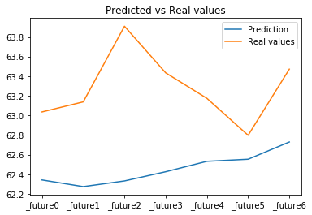

```python
plt.plot(prediction[0], label="Prediction")
plt.plot(Y_test.iloc[0], label="Real values")
plt.title("Predicted vs Real values")
plt.legend()
plt.show()
```

```python
from sklearn.metrics import mean_absolute_error
```

```python
me=mean_absolute_error(prediction[0], Y_test.iloc[0]) #Accuracy error
```

```python
error=[];
nombre=[];
nombre.append("Linear Regression")
print(nombre)
error.append(me)
print(error)
```

```
['Linear Regression']
[0.8240205986241287]
```

```
[62.34282176 62.27482584 62.3328385  62.42657442 62.53277612 62.55392647
 62.72969269]
```

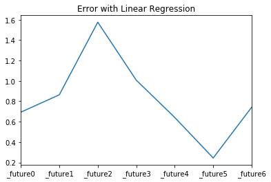

```python
err1=[];
print(prediction[0])
for i in range(1, len(prediction[0])):
    err1=Y_test.iloc[0]-prediction[0]

err1.plot()
plt.title("Error with Linear Regression")
plt.show()
```

## Neural Networks

```python
from sklearn.neural_network import MLPRegressor
```

```python
MLP=MLPRegressor(max_iter=500,hidden_layer_sizes=(100,100,100))
```

```python
MLP.fit(X_train,Y_train)
```

```
MLPRegressor(activation='relu', alpha=0.0001, batch_size='auto', beta_1=0.9,
             beta_2=0.999, early_stopping=False, epsilon=1e-08,
             hidden_layer_sizes=(100, 100, 100), learning_rate='constant',
             learning_rate_init=0.001, max_iter=500, momentum=0.9,
             n_iter_no_change=10, nesterovs_momentum=True, power_t=0.5,
             random_state=None, shuffle=True, solver='adam', tol=0.0001,
             validation_fraction=0.1, verbose=False, warm_start=False)
```

```python
prediction=MLP.predict(X_test)
print("Predicted values: ")
print(prediction)
print("Real values: ")
print(Y_test)
```

```
Predicted values:
[[61.67239258 61.94395685 61.52732151 61.59650479 61.66113305 61.72897831
  61.60208437]]
Real values:
     _future0  _future1  _future2  _future3  _future4  _future5  _future6
481   63.0359   63.1385   63.9091   63.4342   63.1742   62.7977    63.472
```

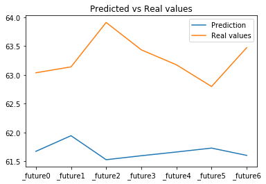

```python
plt.plot(prediction[0], label="Prediction")
plt.plot(Y_test.iloc[0], label="Real values")
plt.title("Predicted vs Real values")
plt.legend()
plt.show()
```

```python
me=mean_absolute_error(prediction[0], Y_test.iloc[0]) #Accuracy error
nombre.append("Neural Networks without random_state")
print(nombre)
error.append(me)
print(error)
```

```
['Linear Regression', 'Neural Networks without random_state']
[0.8240205986241287, 1.6041755050036974]
```

```
[61.67239258 61.94395685 61.52732151 61.59650479 61.66113305 61.72897831
 61.60208437]
```

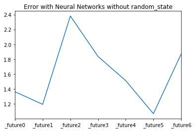

```python
err2=[];
print(prediction[0])
for i in range(1, len(prediction[0])):
    err2=Y_test.iloc[0]-prediction[0]

err2.plot()
plt.title("Error with Neural Networks without random_state")
plt.show()
```

```
Predicted values:
[[61.6853707  61.58886891 61.6823228  61.66626848 61.87417301 61.79729907
  62.04428389]]
Real values:
     _future0  _future1  _future2  _future3  _future4  _future5  _future6
481   63.0359   63.1385   63.9091   63.4342   63.1742   62.7977    63.472
```

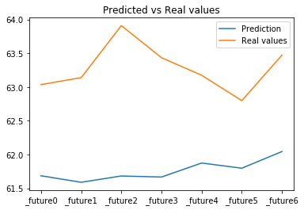

```python
MLP=MLPRegressor(max_iter=500,hidden_layer_sizes=(100,100,100), random_state=42)
MLP.fit(X_train,Y_train)
prediction=MLP.predict(X_test)
print("Predicted values: ")
print(prediction)
print("Real values: ")
print(Y_test)
plt.plot(prediction[0], label="Prediction")
plt.plot(Y_test.iloc[0], label="Real values")
plt.title("Predicted vs Real values")
plt.legend()
plt.show()
```

```python
errorMLP1=mean_absolute_error(prediction[0], Y_test.iloc[0]) #Accuracy error
nombre.append("Neural Network with random_state, hidden_layers=(100,100,100) and max_it=500")
print(nombre)
error.append(errorMLP1)
print(error)
```

```
['Linear Regression', 'Neural Networks without random_state', 'Neural Network with random_state, hidden_layers=(100,100,100) and max_it=500']
[0.8240205986241287, 1.6041755050036974, 1.51757330379845]
```

```
[61.6853707  61.58886891 61.6823228  61.66626848 61.87417301 61.79729907
 62.04428389]
```

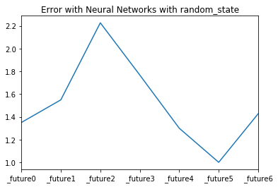

```python
err3=[];
print(prediction[0])
for i in range(1, len(prediction[0])):
    err3=Y_test.iloc[0]-prediction[0]

err3.plot()
plt.title("Error with Neural Networks with random_state")
plt.show()
```

## RandomForest

```python
from sklearn.ensemble import RandomForestRegressor
```

```python
RFR=RandomForestRegressor(n_estimators=1000,max_depth=10)
```

```python
RFR
```

```
RandomForestRegressor(bootstrap=True, criterion='mse', max_depth=10,
                      max_features='auto', max_leaf_nodes=None,
                      min_impurity_decrease=0.0, min_impurity_split=None,
                      min_samples_leaf=1, min_samples_split=2,
                      min_weight_fraction_leaf=0.0, n_estimators=1000,
                      n_jobs=None, oob_score=False, random_state=None,
                      verbose=0, warm_start=False)
```

```python
RFR #Properties of our regressor
```

```
RandomForestRegressor(bootstrap=True, criterion='mse', max_depth=10,
                      max_features='auto', max_leaf_nodes=None,
                      min_impurity_decrease=0.0, min_impurity_split=None,
                      min_samples_leaf=1, min_samples_split=2,
                      min_weight_fraction_leaf=0.0, n_estimators=1000,
                      n_jobs=None, oob_score=False, random_state=None,
                      verbose=0, warm_start=False)
```

```python
RFR.fit(X_train, Y_train)
```

```
RandomForestRegressor(bootstrap=True, criterion='mse', max_depth=10,
                      max_features='auto', max_leaf_nodes=None,
                      min_impurity_decrease=0.0, min_impurity_split=None,
                      min_samples_leaf=1, min_samples_split=2,
                      min_weight_fraction_leaf=0.0, n_estimators=1000,
                      n_jobs=None, oob_score=False, random_state=None,
                      verbose=0, warm_start=False)
```

```
Predicted values:
[[62.62842842 62.74368761 62.9717802  63.20532717 63.33867763 63.23080862
  63.24279431]]
Real values:
     _future0  _future1  _future2  _future3  _future4  _future5  _future6
481   63.0359   63.1385   63.9091   63.4342   63.1742   62.7977    63.472
```

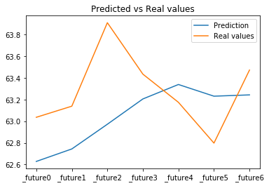

```python
prediction=RFR.predict(X_test)
print("Predicted values: ")
print(prediction)
print("Real values: ")
print(Y_test)
plt.plot(prediction[0], label="Prediction")
plt.plot(Y_test.iloc[0], label="Real values")
plt.title("Predicted vs Real values")
plt.legend()
plt.show()
```

```python
me=mean_absolute_error(prediction[0], Y_test.iloc[0]) #Accuracy error
nombre.append("Random Forest without random_state")
print(nombre)
error.append(me)
print(error)
```

```
['Linear Regression', 'Neural Networks without random_state', 'Neural Network with random_state, hidden_layers=(100,100,100) and max_it=500', 'Random Forest without random_state']
[0.8240205986241287, 1.6041755050036974, 1.51757330379845, 0.3993240787900975]
```

```
[62.62842842 62.74368761 62.9717802  63.20532717 63.33867763 63.23080862
 63.24279431]
```

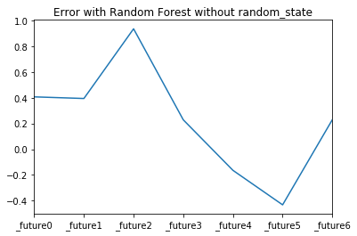

```python
err4=[];
print(prediction[0])
for i in range(1, len(prediction[0])):
    err4=Y_test.iloc[0]-prediction[0]

err4.plot()
plt.title("Error with Random Forest without random_state")
plt.show()
```

## K NEAREST NEIGBORS (KNN)

```python
from sklearn.neighbors import KNeighborsRegressor
```

```
Predicted values:
[[62.61165 62.71465 63.0872  63.5238  63.67165 63.3042  62.98595]]
Real values:
     _future0  _future1  _future2  _future3  _future4  _future5  _future6
481   63.0359   63.1385   63.9091   63.4342   63.1742   62.7977    63.472
```

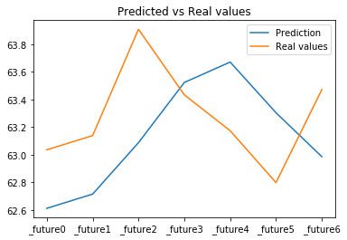

```python
KNN= KNeighborsRegressor(n_neighbors=2)
KNN.fit(X_train, Y_train)
prediction=KNN.predict(X_test)
print("Predicted values: ")
print(prediction)
print("Real values: ")
print(Y_test)
plt.plot(prediction[0], label="Prediction")
plt.plot(Y_test.iloc[0], label="Real values")
plt.title("Predicted vs Real values")
plt.legend()
plt.show()
```

```python
me=mean_absolute_error(prediction[0], Y_test.iloc[0]) #Accuracy error
nombre.append("K Nearest Neighbors")
print(nombre)
error.append(me)
print(error)
```

```
['Linear Regression', 'Neural Networks without random_state', 'Neural Network with random_state, hidden_layers=(100,100,100) and max_it=500', 'Random Forest without random_state', 'K Nearest Neighbors']
[0.8240205986241287, 1.6041755050036974, 1.51757330379845, 0.3993240787900975, 0.4642285714285726]
```

```
[62.61165 62.71465 63.0872  63.5238  63.67165 63.3042  62.98595]
```

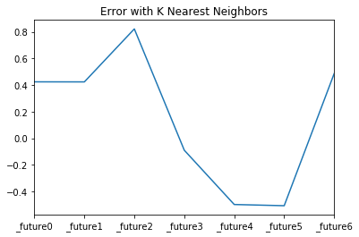

```python
err5=[];
print(prediction[0])
for i in range(1, len(prediction[0])):
    err5=Y_test.iloc[0]-prediction[0]

err5.plot()
plt.title("Error with K Nearest Neighbors")
plt.show()
```

## Домашние задание

1. Улучшить результаты модели MLPRegressor, т.е. добиться ошибки меньше чем в эфире (1.5175) Всегда использовать random_state=42 (там где это применимо)

```
Predicted values:
[[62.12116154 62.25687025 62.07596195 62.20319095 62.26318183 62.3123601
  62.25739791]]
Real values:
     _future0  _future1  _future2  _future3  _future4  _future5  _future6
481   63.0359   63.1385   63.9091   63.4342   63.1742   62.7977    63.472
```

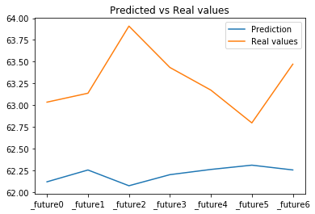

```python
MLP=MLPRegressor(max_iter=1000, hidden_layer_sizes=(50,50,50), random_state=42)
MLP.fit(X_train,Y_train)
prediction=MLP.predict(X_test)
print("Predicted values: ")
print(prediction)
print("Real values: ")
print(Y_test)
plt.plot(prediction[0], label="Prediction")
plt.plot(Y_test.iloc[0], label="Real values")
plt.title("Predicted vs Real values")
plt.legend()
plt.show()
```

```python
me=mean_absolute_error(prediction[0], Y_test.iloc[0]) #Accuracy error
nombre.append("Neural Network with random_state, hidden_layers=(50,50,50) and max_it=1000")
print(nombre)
error.append(me)
print(error)
```

```
['Linear Regression', 'Neural Networks without random_state', 'Neural Network with random_state, hidden_layers=(100,100,100) and max_it=500', 'Random Forest without random_state', 'K Nearest Neighbors', 'Neural Network with random_state, hidden_layers=(50,50,50) and max_it=1000']
[0.8240205986241287, 1.6041755050036974, 1.51757330379845, 0.3993240787900975, 0.4642285714285726, 1.0673536403195385]
```

```
[62.12116154 62.25687025 62.07596195 62.20319095 62.26318183 62.3123601
 62.25739791]
```

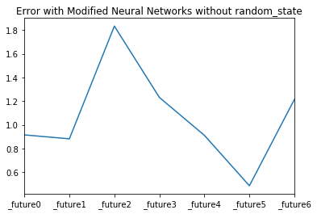

```python
err6=[];
print(prediction[0])
for i in range(1, len(prediction[0])):
    err6=Y_test.iloc[0]-prediction[0]

err6.plot()
plt.title("Error with Modified Neural Networks without random_state")
plt.show()
```

It is not possible to use random_state in Linear Regression or K Nearest Neighbors

### Random Forest with random_state

```
Predicted values:
[[62.62833328 62.7415222  62.96319821 63.19759291 63.3395541  63.24038189
  63.20567572]]
Real values:
     _future0  _future1  _future2  _future3  _future4  _future5  _future6
481   63.0359   63.1385   63.9091   63.4342   63.1742   62.7977    63.472
```

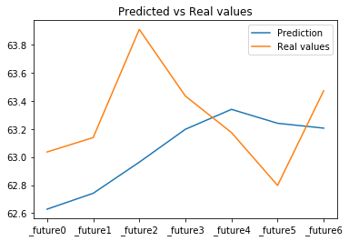

```python
RFR=RandomForestRegressor(n_estimators=1000,max_depth=10, random_state=42)
RFR.fit(X_train, Y_train)
prediction=RFR.predict(X_test)
print("Predicted values: ")
print(prediction)
print("Real values: ")
print(Y_test)
plt.plot(prediction[0], label="Prediction")
plt.plot(Y_test.iloc[0], label="Real values")
plt.title("Predicted vs Real values")
plt.legend()
plt.show()
```

```python
me=mean_absolute_error(prediction[0], Y_test.iloc[0]) #Accuracy error
nombre.append("Random Forest with random_state")
print(nombre)
error.append(me)
print(error)
```

```
['Linear Regression', 'Neural Networks without random_state', 'Neural Network with random_state, hidden_layers=(100,100,100) and max_it=500', 'Random Forest without random_state', 'K Nearest Neighbors', 'Neural Network with random_state, hidden_layers=(50,50,50) and max_it=1000', 'Random Forest with…
[0.8240205986241287, 1.6041755050036974, 1.51757330379845, 0.3993240787900975, 0.4642285714285726, 1.0673536403195385, 0.40877338118316786]
```

```
[62.62833328 62.7415222  62.96319821 63.19759291 63.3395541  63.24038189
 63.20567572]
```

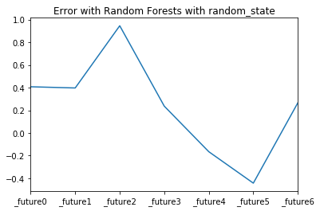

```python
err7=[];
print(prediction[0])
for i in range(1, len(prediction[0])):
    err7=Y_test.iloc[0]-prediction[0]

err7.plot()
plt.title("Error with Random Forests with random_state")
plt.show()
```

As we can see the error in both random forests (with and without random_state) very similar so we can not conclude anything about the difference in using such expresion

1. Взять ТРИ других алгоритма регресси из Sklearn, и попробовать их обучить и добиться минимальной ошибки

## Decision Tree Regressor

```python
import numpy as np
from sklearn.tree import DecisionTreeRegressor
```

```python
dectree=DecisionTreeRegressor()
dectree
```

```
DecisionTreeRegressor(criterion='mse', max_depth=None, max_features=None,
                      max_leaf_nodes=None, min_impurity_decrease=0.0,
                      min_impurity_split=None, min_samples_leaf=1,
                      min_samples_split=2, min_weight_fraction_leaf=0.0,
                      presort=False, random_state=None, splitter='best')
```

```python
dectree=DecisionTreeRegressor(random_state=42)
```

```python
dectree.fit(X_train, Y_train)
```

```
DecisionTreeRegressor(criterion='mse', max_depth=None, max_features=None,
                      max_leaf_nodes=None, min_impurity_decrease=0.0,
                      min_impurity_split=None, min_samples_leaf=1,
                      min_samples_split=2, min_weight_fraction_leaf=0.0,
                      presort=False, random_state=42, splitter='best')
```

```
Predicted values:
[[62.3934 63.0359 63.1385 63.9091 63.4342 63.1742 62.7977]]
Real values:
     _future0  _future1  _future2  _future3  _future4  _future5  _future6
481   63.0359   63.1385   63.9091   63.4342   63.1742   62.7977    63.472
```

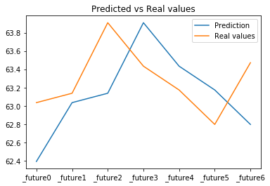

```python
prediction=dectree.predict(X_test)
print("Predicted values: ")
print(prediction)
print("Real values: ")
print(Y_test)
plt.plot(prediction[0], label="Prediction")
plt.plot(Y_test.iloc[0], label="Real values")
plt.title("Predicted vs Real values")
plt.legend()
plt.show()
```

```python
me=mean_absolute_error(prediction[0], Y_test.iloc[0]) #Accuracy error
nombre.append("Decision Tree")
print(nombre)
error.append(me)
print(error)
```

```
['Linear Regression', 'Neural Networks without random_state', 'Neural Network with random_state, hidden_layers=(100,100,100) and max_it=500', 'Random Forest without random_state', 'K Nearest Neighbors', 'Neural Network with random_state, hidden_layers=(50,50,50) and max_it=1000', 'Random Forest with…
[0.8240205986241287, 1.6041755050036974, 1.51757330379845, 0.3993240787900975, 0.4642285714285726, 1.0673536403195385, 0.40877338118316786, 0.47162857142857256]
```

```
[62.3934 63.0359 63.1385 63.9091 63.4342 63.1742 62.7977]
```

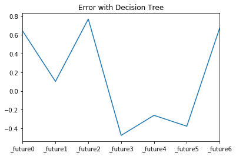

```python
err8=[];
print(prediction[0])
for i in range(1, len(prediction[0])):
    err8=Y_test.iloc[0]-prediction[0]

err8.plot()
plt.title("Error with Decision Tree")
plt.show()
```

## Gaussian Process Regressor

```python
from sklearn import gaussian_process
```

```python
from sklearn.gaussian_process import GaussianProcessRegressor
gpr=GaussianProcessRegressor(random_state=42)
gpr.fit(X_train, Y_train)
```

```
GaussianProcessRegressor(alpha=1e-10, copy_X_train=True, kernel=None,
                         n_restarts_optimizer=0, normalize_y=False,
                         optimizer='fmin_l_bfgs_b', random_state=42)
```

```
Predicted values:
[[21.8270954  21.97229942 22.04861017 22.26983719 22.17671212 22.08597217
  21.98930118]]
Real values:
     _future0  _future1  _future2  _future3  _future4  _future5  _future6
481   63.0359   63.1385   63.9091   63.4342   63.1742   62.7977    63.472
```

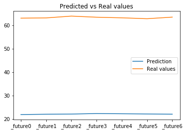

```python
prediction=gpr.predict(X_test)
print("Predicted values: ")
print(prediction)
print("Real values: ")
print(Y_test)
plt.plot(prediction[0], label="Prediction")
plt.plot(Y_test.iloc[0], label="Real values")
plt.title("Predicted vs Real values")
plt.legend()
plt.show()
```

```python
me=mean_absolute_error(prediction[0], Y_test.iloc[0]) #Accuracy error
nombre.append("Gaussian Process")
print(nombre)
error.append(me)
print(error)
```

```
['Linear Regression', 'Neural Networks without random_state', 'Neural Network with random_state, hidden_layers=(100,100,100) and max_it=500', 'Random Forest without random_state', 'K Nearest Neighbors', 'Neural Network with random_state, hidden_layers=(50,50,50) and max_it=1000', 'Random Forest with…
[0.8240205986241287, 1.6041755050036974, 1.51757330379845, 0.3993240787900975, 0.4642285714285726, 1.0673536403195385, 0.40877338118316786, 0.47162857142857256, 41.22739605181159]
```

```
[21.8270954  21.97229942 22.04861017 22.26983719 22.17671212 22.08597217
 21.98930118]
```

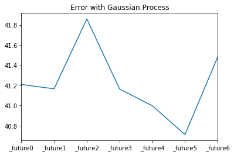

```python
err9=[];
print(prediction[0])
for i in range(1, len(prediction[0])):
    err9=Y_test.iloc[0]-prediction[0]

err9.plot()
plt.title("Error with Gaussian Process")
plt.show()
```

## Ridge regression

```python
from sklearn.linear_model import RidgeCV
```

```python
Ridge= RidgeCV()
```

```python
Ridge
```

```
RidgeCV(alphas=array([ 0.1,  1. , 10. ]), cv=None, fit_intercept=True,
        gcv_mode=None, normalize=False, scoring=None, store_cv_values=False)
```

```
Predicted values:
[[62.3798274  62.33235154 62.37715222 62.4735418  62.56530432 62.607166
  62.7535754 ]]
Real values:
     _future0  _future1  _future2  _future3  _future4  _future5  _future6
481   63.0359   63.1385   63.9091   63.4342   63.1742   62.7977    63.472
```

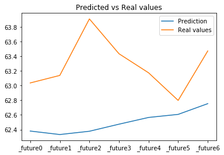

```python
Ridge.fit(X_train, Y_train)
prediction= Ridge.predict(X_test)
print("Predicted values: ")
print(prediction)
print("Real values: ")
print(Y_test)
plt.plot(prediction[0], label="Prediction")
plt.plot(Y_test.iloc[0], label="Real values")
plt.title("Predicted vs Real values")
plt.legend()
plt.show()
```

```python
me=mean_absolute_error(prediction[0], Y_test.iloc[0]) #Accuracy error
nombre.append("Ridge Regression")
print(nombre)
error.append(me)
print(error)
```

```
['Linear Regression', 'Neural Networks without random_state', 'Neural Network with random_state, hidden_layers=(100,100,100) and max_it=500', 'Random Forest without random_state', 'K Nearest Neighbors', 'Neural Network with random_state, hidden_layers=(50,50,50) and max_it=1000', 'Random Forest with…
[0.8240205986241287, 1.6041755050036974, 1.51757330379845, 0.3993240787900975, 0.4642285714285726, 1.0673536403195385, 0.40877338118316786, 0.47162857142857256, 41.22739605181159, 0.7818116168537556]
```

```
[62.3798274  62.33235154 62.37715222 62.4735418  62.56530432 62.607166
 62.7535754 ]
```

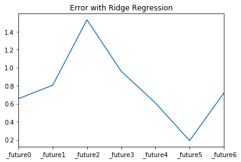

```python
err10=[];
print(prediction[0])
for i in range(1, len(prediction[0])):
    err10=Y_test.iloc[0]-prediction[0]

err10.plot()
plt.title("Error with Ridge Regression")
plt.show()
```

```python
Maximo=0
Minimo=100
maxpos=0 #Maximum position
minpos=0 #Minimum position
for i in range(1,len(error)):
    num=error[i]
    if(num>Maximo):
        Maximo=num
        maxpos=i
    elif(num<Minimo):
        Minimo=num
        minpos=i
print("Maximum error",Maximo, "and this corresponds to ", nombre[maxpos])
print("Minimum error",Minimo, "and this corresponds to ", nombre[minpos])
```

```
Maximum error 41.22739605181159 and this corresponds to  Gaussian Process
Minimum error 0.3993240787900975 and this corresponds to  Random Forest without random_state
```

## Выбоды

As we can see the Gaussian Process Regression is the worst for this example. On the other hand Random Forest Regressor is the best one as the error is the minimum error. Also we can graphic all error lines

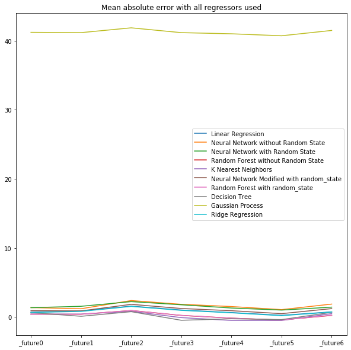

```python
plt.figure(figsize=(10,10))
plt.plot(err1, label="Linear Regression")
plt.plot(err2, label="Neural Network without Random State")
plt.plot(err3, label="Neural Network with Random State")
plt.plot(err4, label="Random Forest without Random State")
plt.plot(err5, label="K Nearest Neighbors")
plt.plot(err6, label="Neural Network Modified with random_state")
plt.plot(err7, label= "Random Forest with random_state")
plt.plot(err8, label="Decision Tree")
plt.plot(err9, label="Gaussian Process")
plt.plot(err10, label="Ridge Regression")
plt.title("Mean absolute error with all regressors used")
plt.legend()
plt.show()
```

The maximum error is clear that is with Gaussian Process Regressor, lets see which one is the minimum

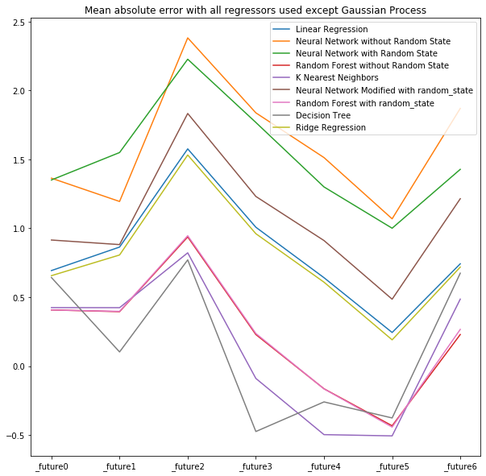

```python
plt.figure(figsize=(10,10))
plt.plot(err1, label="Linear Regression")
plt.plot(err2, label="Neural Network without Random State")
plt.plot(err3, label="Neural Network with Random State")
plt.plot(err4, label="Random Forest without Random State")
plt.plot(err5, label="K Nearest Neighbors")
plt.plot(err6, label="Neural Network Modified with random_state")
plt.plot(err7, label= "Random Forest with random_state")
plt.plot(err8, label="Decision Tree")
plt.plot(err10, label="Ridge Regression")
plt.title("Mean absolute error with all regressors used except Gaussian Process")
plt.legend()
plt.show()
```

The best regressor for this example is Random Forest and there is not so many difference between the one with random_state and the one without random_state. Although it is better for this example without random_state

# Day 1

## Основы Python

```python
print("Hello world!")
```

```
Hello world!
```

```python
#Comentario
```

```python
print("Сегодня Понедельник, 10 февраля")
print("Вы находитесь на интенсиве Skillbox")
print("Интенсив посвящен Data Science")
```

```
Сегодня Понедельник, 10 февраля
Вы находитесь на интенсиве Skillbox
Интенсив посвящен Data Science
```

```python
company="Skillbox"
```

```python
print(company)
```

```
Skillbox
```

```python
course=" Data Science от 0 до про"
full_name=company + ":" + course
print(full_name)
```

```
Skillbox: Data Science от 0 до про
```

```python
salary=100000
tax=0.13
tax_value=salary*tax
print(tax_value)
```

```
13000.0
```

```python
print(f"Моя зарплата:  salary, коэфф. налог = {tax} всего к заплачу в налоговую {tax_value}")
```

```
Моя зарплата:  salary, коэфф. налог = 0.13 всего к заплачу в налоговую 13000.0
```

```python
income={1200,4000,500,90000}
print(income)
```

```
{1200, 500, 90000, 4000}
```

```python
for i in income:
    print(f"Я работала {i}" )

print("Вот и все что я заработал ...")
```

```
Я работала 1200
Я работала 500
Я работала 90000
Я работала 4000
Вот и все что я заработал ...
```

```python
sum(income)
```

```
95700
```

```python
len(income)
```

```
4
```

```python
average_income=sum(income)/len(income)
print(f"В среднем я получал по {average_income} рублей")
```

```
В среднем я получал по 23925.0 рублей
```

```python
income
```

```
{500, 1200, 4000, 90000}
```

```python
usd_rate=64
usd_income=[i/usd_rate for i in income]
```

```python
print(usd_income)
```

```
[18.75, 7.8125, 1406.25, 62.5]
```

Text *Text* **Text** *Text* *Text*

**Вот мы и рассмотрели основы Питона, давайте двигается дальше**

## Разбигаемся с Pandas

```python
import pandas as pd
```

```python
exchange_rate=pd.read_excel("euro.xlsx")
exchange_rate
```

|  | nominal | data | curs | cdx |
| --- | --- | --- | --- | --- |
| 0 | 1 | 2018-01-10 | 68.2103 | Евро |
| 1 | 1 | 2018-01-11 | 67.8841 | Евро |
| 2 | 1 | 2018-01-12 | 68.0586 | Евро |
| 3 | 1 | 2018-01-13 | 68.2562 | Евро |
| 4 | 1 | 2018-01-16 | 68.8174 | Евро |
| 5 | 1 | 2018-01-17 | 69.0243 | Евро |
| 6 | 1 | 2018-01-18 | 69.1730 | Евро |
| 7 | 1 | 2018-01-19 | 69.2582 | Евро |
| 8 | 1 | 2018-01-20 | 69.3953 | Евро |
| 9 | 1 | 2018-01-23 | 69.2650 | Евро |
| 10 | 1 | 2018-01-24 | 69.0702 | Евро |
| 11 | 1 | 2018-01-25 | 69.4484 | Евро |
| 12 | 1 | 2018-01-26 | 69.4580 | Евро |
| 13 | 1 | 2018-01-27 | 69.6073 | Евро |
| 14 | 1 | 2018-01-30 | 69.8513 | Евро |
| 15 | 1 | 2018-01-31 | 69.5424 | Евро |
| 16 | 1 | 2018-02-01 | 69.9322 | Евро |
| 17 | 1 | 2018-02-02 | 69.7921 | Евро |
| 18 | 1 | 2018-02-03 | 70.0958 | Евро |
| 19 | 1 | 2018-02-06 | 70.4959 | Евро |
| 20 | 1 | 2018-02-07 | 70.9294 | Евро |
| 21 | 1 | 2018-02-08 | 70.5310 | Евро |
| 22 | 1 | 2018-02-09 | 70.7713 | Евро |
| 23 | 1 | 2018-02-10 | 71.3943 | Евро |
| 24 | 1 | 2018-02-13 | 71.2450 | Евро |
| 25 | 1 | 2018-02-14 | 71.1670 | Евро |
| 26 | 1 | 2018-02-15 | 71.2329 | Евро |
| 27 | 1 | 2018-02-16 | 70.6718 | Евро |
| 28 | 1 | 2018-02-17 | 70.6471 | Евро |
| 29 | 1 | 2018-02-20 | 69.9001 | Евро |
| ... | ... | ... | ... | ... |
| 487 | 1 | 2019-12-24 | 68.9978 | Евро |
| 488 | 1 | 2019-12-25 | 68.9062 | Евро |
| 489 | 1 | 2019-12-26 | 68.4065 | Евро |
| 490 | 1 | 2019-12-27 | 68.5003 | Евро |
| 491 | 1 | 2019-12-28 | 69.0349 | Евро |
| 492 | 1 | 2019-12-31 | 69.3406 | Евро |
| 493 | 1 | 2020-01-01 | 69.3777 | Евро |
| 494 | 1 | 2020-01-10 | 68.0555 | Евро |
| 495 | 1 | 2020-01-11 | 68.0450 | Евро |
| 496 | 1 | 2020-01-14 | 67.8162 | Евро |
| 497 | 1 | 2020-01-15 | 68.4213 | Евро |
| 498 | 1 | 2020-01-16 | 68.3747 | Евро |
| 499 | 1 | 2020-01-17 | 68.6560 | Евро |
| 500 | 1 | 2020-01-18 | 68.5358 | Евро |
| 501 | 1 | 2020-01-21 | 68.2082 | Евро |
| 502 | 1 | 2020-01-22 | 68.6222 | Евро |
| 503 | 1 | 2020-01-23 | 68.5186 | Евро |
| 504 | 1 | 2020-01-24 | 68.6856 | Евро |
| 505 | 1 | 2020-01-25 | 68.2924 | Евро |
| 506 | 1 | 2020-01-28 | 68.7775 | Евро |
| 507 | 1 | 2020-01-29 | 69.2260 | Евро |
| 508 | 1 | 2020-01-30 | 68.6764 | Евро |
| 509 | 1 | 2020-01-31 | 69.4151 | Евро |
| 510 | 1 | 2020-02-01 | 69.5976 | Евро |
| 511 | 1 | 2020-02-04 | 70.7921 | Евро |
| 512 | 1 | 2020-02-05 | 70.1265 | Евро |
| 513 | 1 | 2020-02-06 | 69.7443 | Евро |
| 514 | 1 | 2020-02-07 | 69.0837 | Евро |
| 515 | 1 | 2020-02-08 | 69.6288 | Евро |
| 516 | 1 | 2020-02-11 | 69.8226 | Евро |

517 rows × 4 columns

```python
exchange_rate.head(10)
```

|  | nominal | data | curs | cdx |
| --- | --- | --- | --- | --- |
| 0 | 1 | 2018-01-10 | 68.2103 | Евро |
| 1 | 1 | 2018-01-11 | 67.8841 | Евро |
| 2 | 1 | 2018-01-12 | 68.0586 | Евро |
| 3 | 1 | 2018-01-13 | 68.2562 | Евро |
| 4 | 1 | 2018-01-16 | 68.8174 | Евро |
| 5 | 1 | 2018-01-17 | 69.0243 | Евро |
| 6 | 1 | 2018-01-18 | 69.1730 | Евро |
| 7 | 1 | 2018-01-19 | 69.2582 | Евро |
| 8 | 1 | 2018-01-20 | 69.3953 | Евро |
| 9 | 1 | 2018-01-23 | 69.2650 | Евро |

```python
exchange_rate.curs
```

```
0      68.2103
1      67.8841
2      68.0586
3      68.2562
4      68.8174
5      69.0243
6      69.1730
7      69.2582
8      69.3953
9      69.2650
10     69.0702
11     69.4484
12     69.4580
13     69.6073
14     69.8513
```

[output cut: 47 more lines]

```python
exchange_rate.curs*100
```

```
0      6821.03
1      6788.41
2      6805.86
3      6825.62
4      6881.74
5      6902.43
6      6917.30
7      6925.82
8      6939.53
9      6926.50
10     6907.02
11     6944.84
12     6945.80
13     6960.73
14     6985.13
```

[output cut: 47 more lines]

```python
exchange_rate["curs_vs_kopeykah"]=exchange_rate.curs*100
exchange_rate.head(10)
```

|  | nominal | data | curs | cdx | curs_vs_kopeykah |
| --- | --- | --- | --- | --- | --- |
| 0 | 1 | 2018-01-10 | 68.2103 | Евро | 6821.03 |
| 1 | 1 | 2018-01-11 | 67.8841 | Евро | 6788.41 |
| 2 | 1 | 2018-01-12 | 68.0586 | Евро | 6805.86 |
| 3 | 1 | 2018-01-13 | 68.2562 | Евро | 6825.62 |
| 4 | 1 | 2018-01-16 | 68.8174 | Евро | 6881.74 |
| 5 | 1 | 2018-01-17 | 69.0243 | Евро | 6902.43 |
| 6 | 1 | 2018-01-18 | 69.1730 | Евро | 6917.30 |
| 7 | 1 | 2018-01-19 | 69.2582 | Евро | 6925.82 |
| 8 | 1 | 2018-01-20 | 69.3953 | Евро | 6939.53 |
| 9 | 1 | 2018-01-23 | 69.2650 | Евро | 6926.50 |

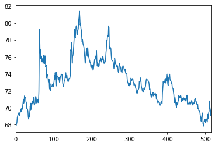

```python
exchange_rate.curs.plot()
```

```python
exchange_rate.curs.describe()
```

```
count    517.000000
mean      73.028540
std        2.735701
min       67.816200
25%       70.771300
50%       72.903700
75%       75.030600
max       81.394200
Name: curs, dtype: float64
```